# Introduction to R

Quantitative Research Methods

2026

## Workshop overview

Welcome to our first R workshop!

In this workshop you will learn the **fundamentals of R**, a powerful, free, open-source programming language widely used in life sciences and data analysis.

By the end of this workshop you will be able to:

- Use R as a **calculator** and store results in variables
- Understand **basic data types**, **vectors**, and **data frames**
- Install and use **R packages** and **functions**
- Set up a **project structure** and import data
- Wrangle data using the **tidyverse**
- Create basic plots using **ggplot2**

# 1. R as a calculator

One of the simplest ways to start using R is as a **calculator**.

You type an expression, run it, and R returns the result.

## 1.1 Basic arithmetic operations

```r
# Addition
3 + 5
```

```
## [1] 8
```

```r
# Subtraction
10 - 4
```

```
## [1] 6
```

```r
# Multiplication
6 * 7
```

```
## [1] 42
```

```r
# Division
20 / 4
```

```
## [1] 5
```

```r
# Exponentiation (2 to the power of 3)
2^3
```

```
## [1] 8
```

### Order of operations

R follows standard mathematical rules (**BODMAS / PEMDAS**).

```r
# Without parentheses
2 + 3 * 4
```

```
## [1] 14
```

```r
# With parentheses
(2 + 3) * 4
```

```
## [1] 20
```

Parentheses allow you to **control the order of operations**.

## 1.2 Assigning values to variables

Instead of calculating a value and losing it, you can **store a value in a variable**.

A variable is simply a **named object that stores a value in the environment**.

We assign values using the **assignment operator** `<-`.

```r
x <- 10
y <- 3
```

Now we can use these variables in calculations.

```r
x + y
```

```
## [1] 13
```

```r
x * y
```

```
## [1] 30
```

### Updating variables

Variables can be overwritten by assigning a new value.

```r
x <- 10
x
```

```
## [1] 10
```

```r
x <- 99
x
```

```
## [1] 99
```

### Naming variables

Good variable names make your code easier to read.

**Rules for variable names**

- Use letters, numbers, `_`, or `.`
- Names must start with a **letter**
- Names are **case-sensitive**. For example, `MyVar` and `myvar` are treated as **different variables**.

### Naming styles

| Style | Example | Description |
| --- | --- | --- |
| snake_case | `plant_height` | Lowercase words separated by underscores |
| camelCase | `plantHeight` | Each word capitalised except the first |

In R, **snake_case is generally preferred** because it is easier to read.

## 1.3 Basic data types in R

Every value in R has a **data type**.

| Type | Description | Example |
| --- | --- | --- |
| `numeric` | Numbers | `3.14`, `42` |
| `character` | Text | `"hello"` |
| `logical` | TRUE/FALSE | `TRUE`, `FALSE` |

Check the type of a value using `class()`.

```r
class(3.14)
```

```
## [1] "numeric"
```

```r
class("hello")
```

```
## [1] "character"
```

```r
class(TRUE)
```

```
## [1] "logical"
```

## 1.4 Vectors

A **vector** is a collection of values of the same type.

```r
heights_cm <- c(105, 150, 112, 80, 132)
heights_cm
```

```
## [1] 105 150 112  80 132
```

```r
genus <- c("Banksia", "Eucalyptus", "Acacia")
genus
```

```
## [1] "Banksia"    "Eucalyptus" "Acacia"
```

R applies mathematical operations **to every element**.

```r
heights_cm / 100
```

```
## [1] 1.05 1.50 1.12 0.80 1.32
```

## 1.5 Data frames

A **data frame** stores tabular data.

```r
plant_data <- data.frame(
  genus = c("Banksia", "Eucalyptus", "Acacia"),
  height_cm = c(150, 300, 200)
)

print(plant_data)
```

```
##        genus height_cm
## 1    Banksia       150
## 2 Eucalyptus       300
## 3     Acacia       200
```

Access a column using `$` or double square brackets `[[ ]]`:

```r
plant_data$height_cm
```

```
## [1] 150 300 200
```

```r
plant_data[["height_cm"]]
```

```
## [1] 150 300 200
```

# 2. R packages and functions

## 2.1 Functions

A **function** performs a specific task.

Example:

```r
mean(c(10, 20, 30))
```

```
## [1] 20
```

```r
length(c(10, 20, 30))
```

```
## [1] 3
```

- `mean()` calculates the average
- `length()` counts the number of elements

## 2.2 Packages

A **package** is a collection of functions that extends what R can do.

## 2.3 Installing and loading packages

You only need to **install a package once**, but you must **load the package from your package library each session**.

```r
# Install packages
install.packages("tidyverse")
```

```r
# Load packages
library(tidyverse)
```

The **tidyverse** is a collection of core R packages designed for data science, including:

- **dplyr** – data manipulation
- **ggplot2** – visualisation
- **readr** – importing data

## 2.4 Using functions from packages

```r
glimpse(plant_data)
```

```
## Rows: 3
## Columns: 2
## $ genus     <chr> "Banksia", "Eucalyptus", "Acacia"
## $ height_cm <dbl> 150, 300, 200
```

`glimpse()` gives a **compact overview of a data frame**.

### Function conflicts

If two packages contain the same function name, you can specify the package:

```r
dplyr::glimpse(plant_data)
```

```
## Rows: 3
## Columns: 2
## $ genus     <chr> "Banksia", "Eucalyptus", "Acacia"
## $ height_cm <dbl> 150, 300, 200
```

This can be helpful when **different packages contain functions with the same name**.

# 3. Project structure

Good project organisation improves **reproducibility**.

```
my_project/
├── my_project.Rproj
├── data/
├── scripts/
└── output/
```

Check your working directory:

```r
getwd()
```

```
## [1] "/Users/lukelikesdirt/Desktop/QRM_2026/07_data_exploration"
```

List files:

```r
list.files("./data")
```

```
## [1] "banksia_data.csv"
```

Read data:

```r
banksia_data <- read_csv(file = "./data/banksia_data.csv")
```

Here, the `read_csv()` looks for the file **banksia_data.csv** in the **data** subdirectory.

# 4. Data wrangling with the tidyverse

Common **dplyr** functions:

| Function | Purpose |
| --- | --- |
| `select()` | choose columns |
| `filter()` | choose rows |
| `mutate()` | create columns |
| `summarise()` | summaries |
| `arrange()` | sort rows |

### Pipes

The pipe `%>%` means **“and then”**.

```r
banksia_data %>%
  select(pair, treatment)
```

```
## # A tibble: 32 × 2
##     pair treatment
##    <dbl> <chr>
##  1     1 control
##  2     2 control
##  3     3 control
##  4     4 control
##  5     6 control
##  6     8 control
##  7     9 control
##  8    10 control
##  9    21 control
## 10    12 control
## # ℹ 22 more rows
```

Here, R reads `banksia_data` *and then* selects the columns *pair* and *treatment*

# 5. Data visualisation with ggplot2

Every ggplot requires:

1. Data
2. Aesthetics (`aes()`)
3. Geometry (`geom_*()`)

### Example boxplot

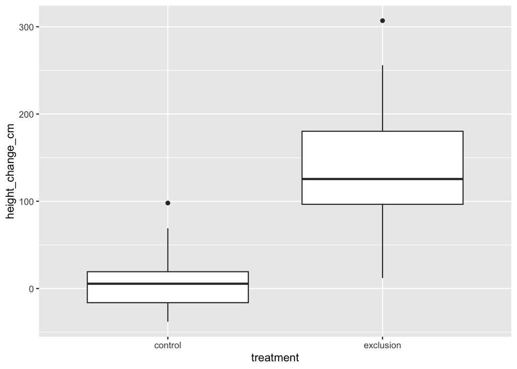

```r
# Create a box plot
banksia_boxplot <- ggplot(
  data = banksia_data,
  aes(x = treatment, y = height_change_cm)
  ) +
  geom_boxplot()

print(banksia_boxplot)
```

### Example scatter plot

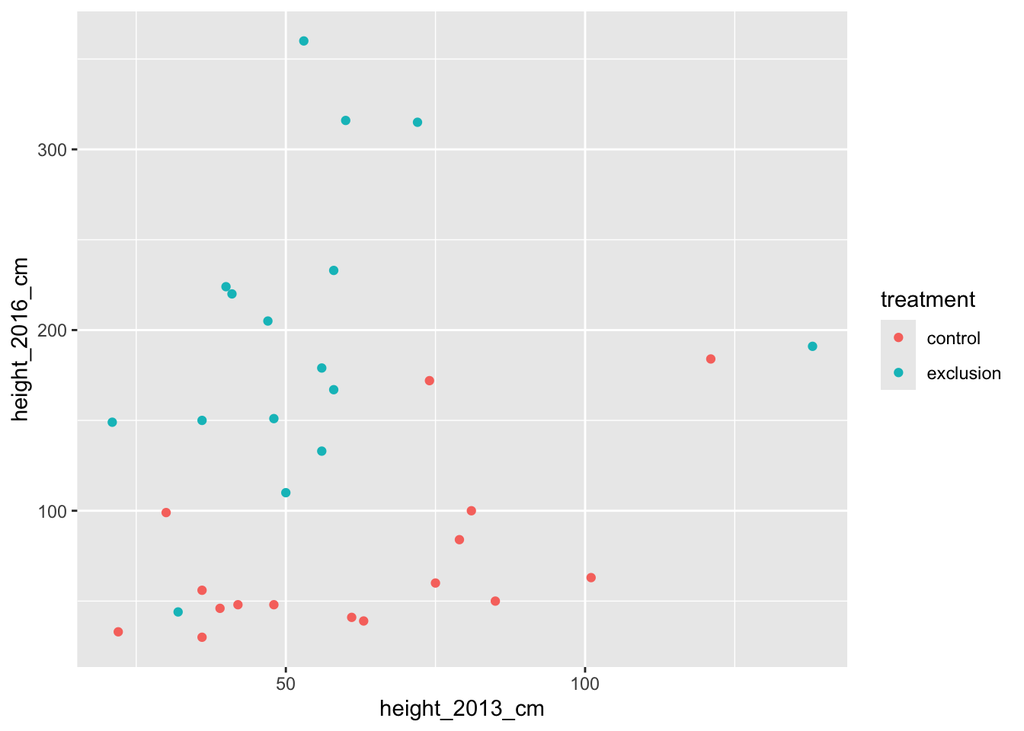

```r
# Create a scatter plot
banksia_scatter <- ggplot(
  data = banksia_data,
  aes(x = height_2013_cm, y = height_2016_cm, colour = treatment)
  ) +
  geom_point()

print(banksia_scatter)
```

### Saving plots

```r
# Save the boxplot
ggsave(
  filename = "output/banksia_boxplot.png",
  plot = banksia_boxplot,
  width = 12,
  height = 8,
  units = "cm"
)
```

# 6. Check your understanding

> **Q1.** Run `x <- 5` and then `y <- x + 3` in R. What value does `y` hold?

> **Q2.** Check the data type of `x` and `y. Are they numeric or character?

> **Q3.** How would you call the `filter()` function from the **dplyr** package without loading the package first?

> **Q4.** What does the pipe operator `%>%` do?

> **Q5.** Pipe the `banksia_data` into `mutate()` function to recompute `hieght_change_cm` as the difference between `hieght_2016_cm` and `hieght_2013_cm` (Hint: `hieght_change_cm = hieght_2016_cm - hieght_2013_cm`)

> **Q6.** Which `geom_*()` function do you think might be used for a *bar* chart